```python
%matplotlib inline
import numpy as np
import random
from numpy import matrix
from numpy import linalg
import matplotlib.pyplot as plt
from scipy import signal
import h5py
from sklearn.decomposition import FastICA, PCA
```

# Describe Approach

## 1. Algorithm

**Input:**

1. Theoritical cumulitive discribution of the function being tested. (In our case: The Mean across all electrodes) **Numerical 1D Vector**
2. The Function we are testing **Numerical 1D Vector**

**Output:**

1. KS Test Statistic (D,D-,D+) **Float**
2. One (Or Two)- Tailed P-Value

**Function Name**

scipy.stats.kstest

### **Step-By-Step Instructions**

$$ $$

**1. Define the hypothesis of uniformity** $$ $$ $$H_0: R_1 = U[0,1]$$ $$H_1: R_1 \neq U[0,1]$$ $$ $$ **2. Arrange data in increasing order** $$ $$ $$R_1 \leq R_2 \leq ... \leq R_n$$ $$ $$ **3. Compute $D^+$ and $D^-$** $$ $$ $$D^+ = max (\frac{i}{N}-R_i), 1 \leq i \leq N$$ $$ $$ $$D^- = max (R_i-\frac{i-1}{N}), 1 \leq i \leq N$$ $$ $$ **4. Compute D** $$ $$ $$ D = max(D^+,D^-) $$ $$ $$ **5. Compute Critical Value based on $\alpha$ provided** $$ $$ $$D_\alpha$$ $$ $$ **6. Compare** $$ $$ $$ D>D_\alpha $$ H_0 hypothesis is rejected. This means H*0 values are not uniform $$ D<D*\alpha $$ H_0 hypothesis is accepted. This means H_0 values are uniform.

## 2. Simulation

**Advantages**

1. Does not depend on the udnerlying cumulative distribution function being tested

**Limitations**

1. Only applies to continuous distributions
2. More sensitive near the center of the distribution than the tails
3. Location, scale, and shape of distribution must be specified to identify the critical region for which the K-S test is valid.

**1. A simulation setting for which the alg with perform very well**

The algorithm will work well with a continuous, normally distribution. $$ $$ **2. A simulation setting for which the alg will not perform well**

The algorithm will not work well for a non-normal / non-continuous data set.

## 3. Analysis

**1. Qualitative visualizations per trial for qualitatively evaluating performance**

After calculating the K-S test statistic (D) for each independent component found by ICA to the mean of all components, we can identify which components had the largest D values. We can then visually examine these components (suspected artifacts) by plotting them, as well as by plotting the original source signal with each of the suspected artifact components removed. From this, we can qualitatively evaluate the performance by determining if the artifact components (those with largest D values) have a similar shape to Eye/EoG artifacts.

**2. Quantitative "score" per trial for quantitatively evaluating performance**

We cannot score the per trial for quantitatively evaluating performance **with real data.** However, we can test the algorithm quantitatively by generating 1000 random numbers for a:

1. Normal Distribution
2. Double Exponential Distribution
3. t (w/ 3 degrees of freedom) Distribution
4. Log-Normal Distribution

We identify the significance level to be $\alpha$ = 0.05, which leads to a critical value of 0.04301.

We then reject the distributions with a D value greater than the critical value of 0.04301. In theory, we should accept the 1st (normal) distribution, and reject other three.

We quantitatively evaluate the performance by running the KS test on "X" number of randomly generated distributions (with "Y" number of normal distributions). Each time the distribution passes the KS test, we add 1 to variable z (starts at 0). After running the KS test on X number of distributions, we calculate the percentage of expected accepted distributions ($\frac{Y}{X} \times 100)$) and compare it to the actual accepted distributions ($\frac{Z}{X} \times 100)$). We then calculate the percentage deviation from the expected, accepted distributions by: $$\frac{Expected - Actual}{Expected}$$

**3. Summary Plot visualization of quantitative scores over all trials (often a histogram)**

We can plot a summary of the quantitative scores over all trials using a histogram. Where the x-axis represents: various ranges for percentage deviation of the resulting number of accepted distributions to the expected. The y-axis represents: the quantity of simulations that fall within a given range of percent deviation. Each histogram should represent the results for one distinct number of randomly generated distributions. Therefore, multiple histograms must be used if we were to test the KS test with varying numbers of total (X) distributions.

# Step-By-Step Code for KS Test

**Generate a Test Distribution**

```python
test_matrix = np.random.randint(11, size=(1, 10))
print(test_matrix)
```

```
[[1 7 2 7 0 9 0 2 0 9]]
```

$$ $$

**1. Define the hypothesis of uniformity** $$ $$ $$H_0: R_1 = U[0,1]$$ $$H_1: R_1 \neq U[0,1]$$ $$ $$ **2. Arrange data in increasing order** $$ $$ $$R_1 \leq R_2 \leq ... \leq R_n$$ $$ $$

```python
sorted_test_matrix = np.sort(test_matrix)
sorted_test_matrix = np.matrix(sorted_test_matrix)
print(sorted_test_matrix)
N = np.size(sorted_test_matrix)
print(N)
```

```
[[0 0 0 1 2 2 7 7 9 9]]
10
```

**3. Compute $D^+$ and $D^-$** $$ $$ $$D^+ = max (\frac{i}{N}-R_i), 1 \leq i \leq N$$ $$ $$ $$D^- = max (R_i-\frac{i-1}{N}), 1 \leq i \leq N$$ $$ $$

```python
D_plus = np.zeros(N+1)
D_minus = np.zeros(N+1)
for i in range(1,N+1):
    D_plus[i] = (i/N) - (sorted_test_matrix[:,i-1])
    D_minus[i] = (sorted_test_matrix[:,i-1]) - ((i-1)/N)
print(D_plus)
print(D_minus)
D_plus_max = np.max(D_plus)
print(D_plus_max)
D_minus_max = np.max(D_minus)
print(D_minus_max)
```

```
[ 0.   0.1  0.2  0.3 -0.6 -1.5 -1.4 -6.3 -6.2 -8.1 -8. ]
[ 0.   0.  -0.1 -0.2  0.7  1.6  1.5  6.4  6.3  8.2  8.1]
0.3
8.2
```

**4. Compute D** $$ $$ $$ D = max(D^+,D^-) $$ $$ $$

```python
D_two_maxes = [D_plus_max, D_minus_max]
print(D_two_maxes)
D = np.max(D_two_maxes)
print(D)
```

```
[0.29999999999999999, 8.1999999999999993]
8.2
```

# KS Test on Real Data

```python
#Number of time steps
n_samples = 5000

#Downsampling the Time steps (Value of 1 means no time downsampling)
downsample_time = 10

#500th data point = 1000 ms
start_time_step = 500
end_time_step = start_time_step + downsample_time*n_samples
time_step_increment = downsample_time

#500Hz sampling rate
samples_per_ms = 0.5

#Time scaling factor for x axis
time_scaling_factor = np.reciprocal(samples_per_ms)

#X-Axis
time_step_axis = np.arange(start=time_scaling_factor*start_time_step, stop=time_scaling_factor*end_time_step, step=time_scaling_factor*time_step_increment)

#Number of electrodes to import + 1

#ex. Number of electrodes = 4
#    n_electrodes = 5

n_electrodes = 7
n_components = n_electrodes - 1


#FastICA Parameters
max_iter = 2000
tol = 0.001
whiten = False
```

```python
f = h5py.File('A00051826/full_A00051826_01.mat', 'r')
data = np.array((f['result']['data']))

electrodes = np.zeros((n_electrodes, n_samples))
for x in range(1,n_electrodes):

    electrodes[x, :] = data[start_time_step:end_time_step:time_step_increment,x];

electrodes = np.delete(electrodes, (0), axis=0)
source_signal = electrodes.T
```

```python
ica = FastICA(n_components=n_electrodes, algorithm='parallel', whiten=whiten, fun='logcosh', fun_args=None, max_iter=max_iter, tol=tol, w_init=None, random_state=None)
ica_ind_component_real_data = ica.fit_transform(source_signal)
```

```
C:\Program Files\Anaconda3\lib\site-packages\sklearn\decomposition\fastica_.py:290: UserWarning: Ignoring n_components with whiten=False.
  warnings.warn('Ignoring n_components with whiten=False.')
```

## 1. Find mean value across all independent components

```python
mean=np.zeros(n_samples)
for x in range(n_components):
    mean = np.add(mean, ica_ind_component_real_data[:,x])
mean = mean/n_components
```

## 2. Arrange the values for each independent component in increasing order

```python
sorted_ica_ind_component_real_data=np.zeros((n_components,n_samples))
for x in range(n_components):
    sorted_ica_ind_component_real_data[x] = np.sort(ica_ind_component_real_data[:,x])

print(sorted_ica_ind_component_real_data)
N = n_samples
```

```
[[-29.05775475 -27.72821809 -27.7124494  ...,  27.33412738  27.91205478
   28.73880623]
 [-29.65051899 -28.07909185 -26.20781705 ...,  28.14255026  28.76211082
   29.86364825]
 [-29.17953599 -29.07902507 -26.83926972 ...,  26.9118566   27.36566223
   33.18657916]
 [-27.84679928 -24.98113052 -23.99272117 ...,  21.45186003  21.87955891
   24.39685426]
 [-22.29485182 -22.11641828 -22.08801655 ...,  21.10945039  21.7787469
   22.67476929]
 [-24.65144076 -22.28256773 -21.54630958 ...,  21.15549053  22.56163638
   23.92907623]]
```

## 3. Compute $D^+$ and $D^-$

```python
sorted_ica_ind_component_real_data = np.matrix(sorted_ica_ind_component_real_data)
D_plus=np.zeros((n_components,n_samples))
D_minus=np.zeros((n_components,n_samples))
D_plus_max=np.zeros((n_components,1))
D_minus_max=np.zeros((n_components,1))

for a in range(n_components):
    for i in range(N):
        D_plus[a,i] = ((i+1)/N) - (sorted_ica_ind_component_real_data[a,i])
        D_minus[a,i] = (sorted_ica_ind_component_real_data[a,i]) - (((i+1)-1)/N)

for a in range(n_components):
    D_plus_max[a] = np.max(D_plus[a,:])
    D_minus_max[a] = np.max(D_minus[a,:])

print(D_plus_max)
print(D_minus_max)
```

```
[[ 29.05795475]
 [ 29.65071899]
 [ 29.17973599]
 [ 27.84699928]
 [ 22.29505182]
 [ 24.65164076]]
[[ 27.73900623]
 [ 28.86384825]
 [ 32.18677916]
 [ 23.39705426]
 [ 21.67496929]
 [ 22.92927623]]
```

## 4. Compute $ D = max(D^+,D^-) $

```python
D=np.zeros(n_components)
for a in range(n_components):
    if D_plus_max[a] > D_minus_max[a]:
        D[a] = D_plus_max[a]
    else:
        D[a] = D_minus_max[a]
print(D)
```

```
[ 29.05795475  29.65071899  32.18677916  27.84699928  22.29505182
  24.65164076]
```

## 5. Order components by max D

```python
component_labels=np.zeros(n_components)
for i in range(1,n_components+1):
    component_labels[i-1] = i

component_labels = np.matrix(component_labels)
D = np.matrix(D)

D_labeled = np.concatenate([D,component_labels])
Sorted_D = np.argsort(D) + 1
print(D_labeled)
```

```
[[ 29.05795475  29.65071899  32.18677916  27.84699928  22.29505182
   24.65164076]
 [  1.           2.           3.           4.           5.           6.        ]]
```

```python
print('Components from least to greatest D: ' + str(Sorted_D))
```

```
Components from least to greatest D: [[5 6 4 1 2 3]]
```

## 6. Plot Largest D Component Before Removing

```
3.0
```

```
C:\Program Files\Anaconda3\lib\site-packages\ipykernel\__main__.py:4: VisibleDeprecationWarning: using a non-integer number instead of an integer will result in an error in the future
```

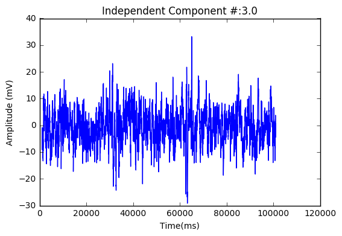

```python
x = np.matrix(Sorted_D)
x = float(Sorted_D[:,n_components-1])
print(x)
plt.plot(time_step_axis, ica_ind_component_real_data[:,x-1])
plt.title('Independent Component #:' + str(x))
plt.ylabel('Amplitude (mV)')
plt.xlabel('Time(ms)')
plt.show()
```

## 7. Remove Component with Largest D Value

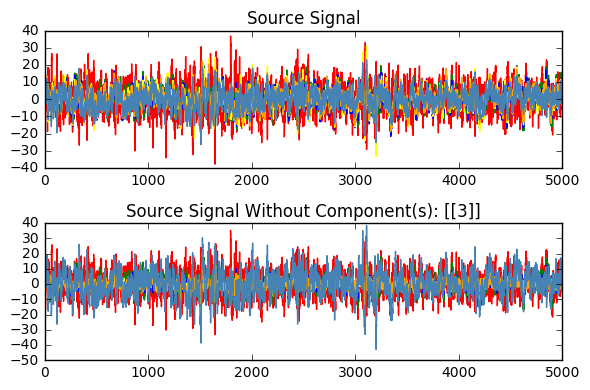

```python
weight = np.copy(ica.mixing_)
x = int(x)

#Components to remove
input_components_to_remove = np.matrix([x]);
components_to_remove = input_components_to_remove - 1;

for number in components_to_remove:
    weight[:, number] = 0;

#Generate original source with removed independent component
component_removed_source_signal = np.copy(np.dot(ica_ind_component_real_data, weight.T))

models = [source_signal,component_removed_source_signal]
names = ['Source Signal','Source Signal Without Component(s): ' + str(input_components_to_remove)]
colors = ['red','green','blue', 'yellow','orange','steelblue','purple']

for ii, (model, name) in enumerate(zip(models, names), 1):
    plt.subplot(2, 1, ii)
    plt.title(name)
    for sig, color in zip(model.T, colors):
        plt.plot(sig, color=color)

plt.tight_layout()
plt.show()
```